# E-commerce Analysis with Dashboard

**Author:** Muhammad Saad  
**Date:** January 19, 2026  
**Dataset:** Olist Brazilian E-commerce  
**Tools:** SQL, Power BI, DAX

This analysis investigates the key drivers of business growth for Olist, a leading Brazilian e-commerce marketplace. The study focuses on how various operational parameters influence two primary KPIs: **Total Revenue** and **Order Volume**

## Executive Summary: Olist E-commerce Performance Analysis (2016–2018)

This analysis provides a comprehensive overview of Olist’s ecosystem, evaluating the performance of customers, sellers, and logistics across Brazil.

## Business Questions

The primary objectives of this analysis are twofold:

- **Geographic and Financial Mapping:** To identify the specific regions (cities) and channels (sellers) that generate the highest order volume and revenue.
- **Trend Identification:** To pinpoint high-demand product categories that currently command the most market demand and consumer interest.

By synthesizing order volume and revenue patterns across cities, sellers, and categories, this study provides actionable insights to support **data-driven decision-making**. The goal is to enable the business to prioritize high-performing segments and optimize overall commercial strategy.

## Dataset Overview

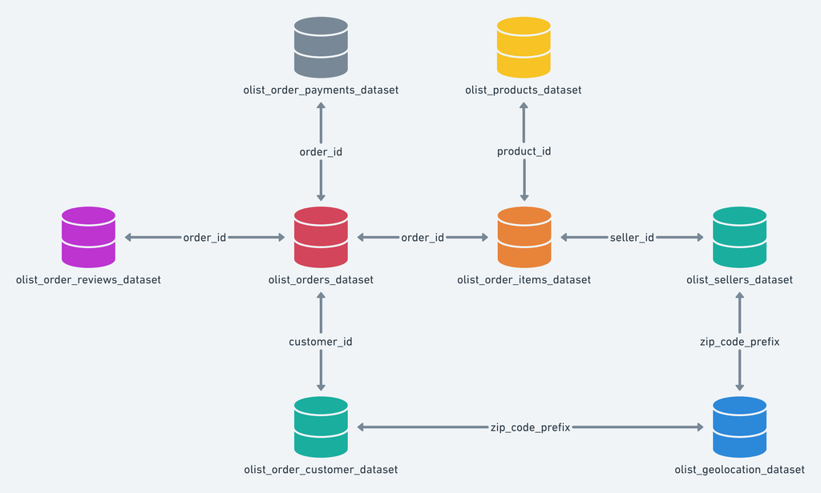

The dataset utilized in this analysis is a publicly available collection of anonymized data provided by **Olist** (curated by Francisco Magioli, Leo Dabague, and Andre Sionek) and hosted on **[Kaggle](https://www.kaggle.com)** under [License](https://creativecommons.org/licenses/by-nc-sa/4.0/). It offers a comprehensive view of the Brazilian e-commerce landscape, spanning from **September 2016 to October 2018**.

### ➤ Data Structure & Composition

The information is organized into **nine CSV files**, capturing various dimensions of the marketplace:

- **Core Transactions**: `Orders` (99,441 rows), `Order Items` (112,650 rows), and `Payments` (103,886 rows).
- **Participants**: `Customers` and `Sellers`.
- **Product Details**: `Products` (32,951 rows) and `Product Category Name Translation` (English mapping).
- **Customer Feedback**: `Reviews` (99,223 rows).
- **Logistics**: `Geolocation` data for spatial analysis.

### ➤ Privacy & Data Integrity

To ensure the highest standards of data ethics and quality, the following measures were applied:

- **Anonymization**: All Personally Identifiable Information (**PII**), such as specific home addresses and credit card numbers, has been removed to protect **user privacy**.
- **ROCCC Standards**: The dataset fulfills all **ROCCC** criteria (**R**eliable, **O**riginal, **C**omprehensive, **C**urrent, and **C**ited), ensuring it is high-quality for professional data analysis.
- **Objective**: The data is used strictly for identifying commercial trends and operational performance.

For a technical deep dive into specific field definitions and data types, please refer to the accompanying `metadata_about_datasets.txt` file.

## Technical Analysis: SQL Implementation

In this phase, the raw data was transformed into actionable insights using SQL. The process involved rigorous data loading, schema verification, and the execution of complex queries to address critical business questions.

### ➤ Data Ingestion & Environment Setup

Before performing the analysis, the nine CSV datasets were imported into a **MySQL** relational database.

- **Data Loading**: Used the `LOAD DATA LOCAL INFILE` command to efficiently import large datasets into the database.
- **Integrity Management**: Tables were configured with appropriate data types to ensure high precision for financial and temporal calculations.

### ➤ Analytical Scope

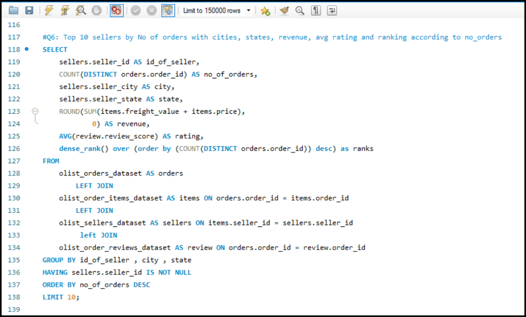

I developed **14** targeted queries to evaluate Olist’s operational and commercial performance:

### ➤ Advanced SQL Techniques Applied

To extract these insights, I utilized a comprehensive suite of SQL functions and logic:

- **Complex Joins**: Implemented multi-table `JOIN`, `LEFT JOIN`, and `RIGHT JOIN` operations to unify disparate datasets (e.g., linking products to English translations).
- **Window Functions**: Used `DENSE_RANK()` for competitive ranking of sellers.
- **Conditional Logic**: Employed `CASE` statements to categorize delivery statuses and segment payment types.
- **Date Manipulation**: Used `DATEDIFF` to calculate shipping speeds and `DATE_FORMAT` for time-series trend analysis.
- **Aggregation**: Leveraged `SUM`, `COUNT`, `AVG`, `ROUND`, and `DISTINCT` within `GROUP BY` and `ORDER BY` clauses to synthesize raw data.
- **Subqueries**: Utilized nested queries to perform multi-level data aggregations.

For the full source code and logic of these calculations, please refer to the attached `SQL_queries.sql` file.

## Data viz and Data Modeling

To transition to visual insights, I prepared the data using **SQL Views** for each dataset within the **RDBMS** to ensure a clean import process.

### ➤ Data Modeling

Once loaded into **Power BI**, a robust data model was established:

- **Core Tables**: Centered on `Orders` and `Order_Items` as the primary fact tables.
- **Relationships**: Power BI automatically mapped connections between datasets, which I refined into a functional Star Schema.
- **Dynamic Filtering**: I enabled **cross-filtering (both directions)**, ensuring the dashboard responds dynamically to any selected field or category.

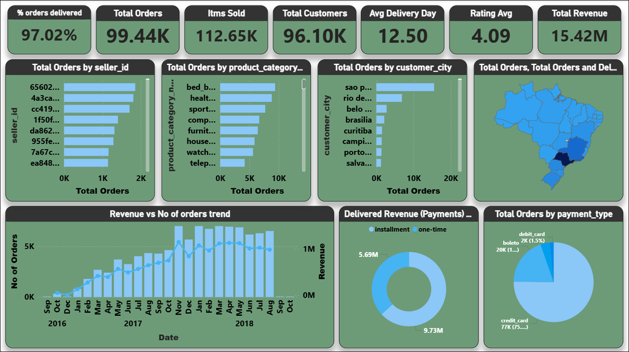

## Dashboard Overview: Olist Interactive Analytics

I developed a fully dynamic dashboard to visualize the Olist ecosystem, transforming complex SQL outputs into intuitive visual narratives.

### ➤ Strategic KPIs

[figure not shown]

The dashboard features seven high-level Key Performance Indicators (KPIs) for instant health monitoring:

- **Customer Reach**: 96.10K Total Customers across 99.44K Orders.
- **Operational Success**: 97.02% Delivery Rate with a 12.5-day average fulfillment cycle.
- **Financial & Quality Growth**: 15.42M Total Revenue with a solid 4.09 average rating.

### ➤ Comparative Analysis (Bar & Map Charts)

[figure not shown]

- **Market Distribution**: Three bar charts rank performance by **Seller ID**, **Product Category**, and **Customer City**, identifying São Paulo as the leading hub.
- **Geographic Density**: A map chart visualizes order concentration by state, highlighting regional market penetration across Brazil.

## Key Insights: Olist Business Performance (2016–2018)

This section highlights the critical trends and metrics identified during the analysis of Olist’s operations.

### ➤ Operational Excellence and Growth

- **Order Fulfillment**: Maintained a high delivery success rate of 97.02% with average fulfillment cycle of **12.5** days.
- **Market Expansion**: Successfully scaled operations from **45.10K orders** in 2017 to **54.01K orders** in 2018, driving a revenue increase from **R$ 6.92M** to **R$ 8.45M**.
- **Customer Base**: Reached a total of **96.10K** unique customers across **99.44K total orders**, indicating a vast but largely single-purchase customer base.

### ➤ Payment Dynamics & Consumer Behavior

The analysis reveals a sharp divide in purchasing behavior based on payment structure:

[output not shown]

### ➤ Seller Ecosystem

- **High Fragmentation**: The platform supports over **3,000 active sellers**.
- **Balanced Distribution**: No single seller dominates the market, with all individual sellers processing fewer than 2,000 orders, ensuring a competitive and diverse marketplace.

## Strategic Business Recommendations

Based on the data insights from the Olist e-commerce analysis, the following strategic actions are recommended to optimize revenue and customer retention:

### ➤ Capitalize on Installment-Driven Revenue

- **Strategic Promotion**: Olist should actively promote installment plans, particularly for high-ticket items.
- **Revenue Optimization**: Given the high-interest environment in Brazil, expanding installment options allows the business to capture more value while making expensive products more accessible.
- **Category Alignment**: Since the top categories (Bed & Bath, Health & Beauty) already dominate installment sales, targeted marketing in these segments will directly boost the bottom line.

### ➤ Targeted Demographic Focus

The top seven product categories (each exceeding 5,000 orders) are primarily related to **Household Goods** and **Teenager/Lifestyle products**.

- **Segment Targeting**: Marketing efforts should be specifically tailored toward teenagers and women, who drive the volume in these high-performing categories.
- **Integrated Financing**: Combining these popular categories with “Easy-to-Pay” installment options will lower the barrier to entry for younger consumers and head-of-household buyers.

### ➤ Customer Retention & Loyalty Programs

Data shows that the vast majority of Olist’s **96.10K customers** are unique, one-time shoppers.

- **Incentivized Re-purchasing**: To improve the Customer Lifetime Value (CLV), the business should implement loyalty rewards or “old customer” discounts.
- **Frictionless Returns**: Offering exclusive installment terms or early-access deals to returning customers will encourage loyalty and transition the platform from a single-transaction marketplace to a recurring shopping destination.

## Project Limitations

To ensure a transparent and objective analysis, it is important to acknowledge the specific constraints of the Olist dataset:

- **Financial Scope**: The dataset lacks cost-of-goods-sold (COGS) and operational expense data, meaning the analysis is restricted to **Gross Revenue** rather than net profit.
- **Geographic Focus**: The findings are exclusively based on transactions within **Brazil**, and may not be applicable to other international e-commerce markets.
- **Product Granularity**: Data is categorized by **product segment** (e.g., “Health & Beauty”) rather than specific product names or SKUs, which limits the ability to perform a deep-dive inventory or brand-level analysis.
- **Economic Variables**: While installment payments are a major factor, the dataset does not include **specific interest rates** or financing fees, preventing a more granular financial impact study.

## Future Enhancements

To further evolve this project, the following analyses could be conducted as more granular data becomes available:

- **Financial & Profitability Modeling**: By integrating Cost of Goods Sold (COGS) and operational expenses, the analysis could shift from gross revenue to net profit margins and ROI.